# Lead Scoring Exercise

11/20/2021

## Overview

Lead scoring is a strategy that marketing and sales teams use to identify which prospects are most valuable to a company in their current sales funnel. In this exercise, I leverage a logit model to score leads to help identify prospects who are more likely to convert.

For each prospect, I calculate a score, the predicted response probability, predicted lift, and compare with the actual response to evaluate the accuracy of my model. Through this model, I improve average profit per name from -2 dollars to 0.26 dollars, and total profit per name from -600 dollars to 78 dollars.

```r
# Clear All Variables & Clear Screen
rm(list=ls())
cat("\014")

# Read in the Data
data.training = read.csv("~/Desktop/MSBA/Customer_Analytics/Ex4_scoring/Data_Estimation_R.csv")
data.testing = read.csv("~/Desktop/MSBA/Customer_Analytics/Ex4_scoring/Data_Holdout_R.csv")

# Explore the data
str(data.training)
summary(data.training)
```

## Analysis

- **Logit Model**: Prediction of y (i.e., the decision to join the club) as a function of the available scoring variables x (gender and all hl…) using a Logit model.

```r
# Binary Logit Model
glm.model <- glm(y ~ hl1 + hl2 + hl3 +  hl5 + hl6 + gender , family=binomial(link='logit'), data=data.training)

# Display Results
summary(glm.model)
```

```
##
## Call:
## glm(formula = y ~ hl1 + hl2 + hl3 + hl5 + hl6 + gender, family = binomial(link = "logit"),
##     data = data.training)
##
## Deviance Residuals:
##     Min       1Q   Median       3Q      Max
## -1.6854  -0.9444  -0.6260   1.1212   2.1831
##
## Coefficients:
##              Estimate Std. Error z value Pr(>|z|)
## (Intercept) -0.928404   0.361689  -2.567  0.01026 *
## hl1          0.005733   0.001840   3.115  0.00184 **
## hl2         -0.045830   0.026570  -1.725  0.08455 .
## hl3         -0.068239   0.017004  -4.013 5.99e-05 ***
## hl5          0.004349   0.026228   0.166  0.86830
## hl6         -0.004919   0.017404  -0.283  0.77746
## gender      -0.016632   0.344941  -0.048  0.96154
## ---
## Signif. codes:  0 '***' 0.001 '**' 0.01 '*' 0.05 '.' 0.1 ' ' 1
##
## (Dispersion parameter for binomial family taken to be 1)
##
##     Null deviance: 261.37  on 199  degrees of freedom
## Residual deviance: 234.26  on 193  degrees of freedom
## AIC: 248.26
##
## Number of Fisher Scoring iterations: 4
```

- **Calculating predicted response rate and lift**: Using the logit model, I scored all individuals in the Testing sample. I calculated for all prospects in the Testing sample, the (a) Predicted Response Rate, and (b) Lift. The results below show the calculations for the first 10 Names.

```r
# Predicting Buy/No Buy for the 300 TESTING IDs based on the Model Estimates
(prediction.testing <- data.frame(ID = data.testing$id,
                                  BinaryLogitProbability = predict(glm.model, data.testing, type = c("response")),
                                  BinaryLogitPredict     = round(predict(glm.model, data.testing, type = c("response")), digits = 0)))

sum(prediction.testing["BinaryLogitPredict"])

sum(prediction.testing["BinaryLogitProbability"])

# Added Lift to the Forecast. Lift is simply the predicted response rate divided by the average response rate of the Training sample
prediction.testing$lift = prediction.testing$BinaryLogitProbability/mean(data.training$y)
```

```r
head(prediction.testing, 10)
```

|  | ID | BinaryLogitProbability | BinaryLogitPredict | lift |
| --- | --- | --- | --- | --- |
| 1 | 201 | 0.4783915 | 0 | 1.3288654 |
| 2 | 202 | 0.5317304 | 1 | 1.4770288 |
| 3 | 203 | 0.2980727 | 0 | 0.8279797 |
| 4 | 204 | 0.6968386 | 1 | 1.9356628 |
| 5 | 205 | 0.2443930 | 0 | 0.6788694 |
| 6 | 206 | 0.3819674 | 0 | 1.0610205 |
| 7 | 207 | 0.5696267 | 1 | 1.5822965 |
| 8 | 208 | 0.3056892 | 0 | 0.8491368 |
| 9 | 209 | 0.4225614 | 0 | 1.1737816 |
| 10 | 210 | 0.4485039 | 0 | 1.2458442 |

- **Confusion Matrix**: The confusion matrix is the cross-tab of predicted response against actual response. Using the matrix, I evaluated the performance of the classification model on a set of test data for which the true values are known. The accuracy of the model is 65.7%.

```r
library(gmodels)
CrossTable(data.testing$y, prediction.testing$BinaryLogitPredict,prop.r=TRUE, prop.c=FALSE, prop.t=FALSE,
           prop.chisq=FALSE, dnn = c("Real Response", "Predicted Response"))
```

```
##
##
##    Cell Contents
## |-------------------------|
## |                       N |
## |           N / Row Total |
## |-------------------------|
##
##
## Total Observations in Table:  300
##
##
##               | Predicted Response
## Real Response |         0 |         1 | Row Total |
## --------------|-----------|-----------|-----------|
##             0 |       165 |        35 |       200 |
##               |     0.825 |     0.175 |     0.667 |
## --------------|-----------|-----------|-----------|
##             1 |        68 |        32 |       100 |
##               |     0.680 |     0.320 |     0.333 |
## --------------|-----------|-----------|-----------|
##  Column Total |       233 |        67 |       300 |
## --------------|-----------|-----------|-----------|
##
##
```

- **Response Probability Chart**: Because there is a cost to sending out invitation, I’d like to target prospects that have higher likelihoods of responding. To do so, I sorted the probability responses from best to worst and created a Response Probability Chart.

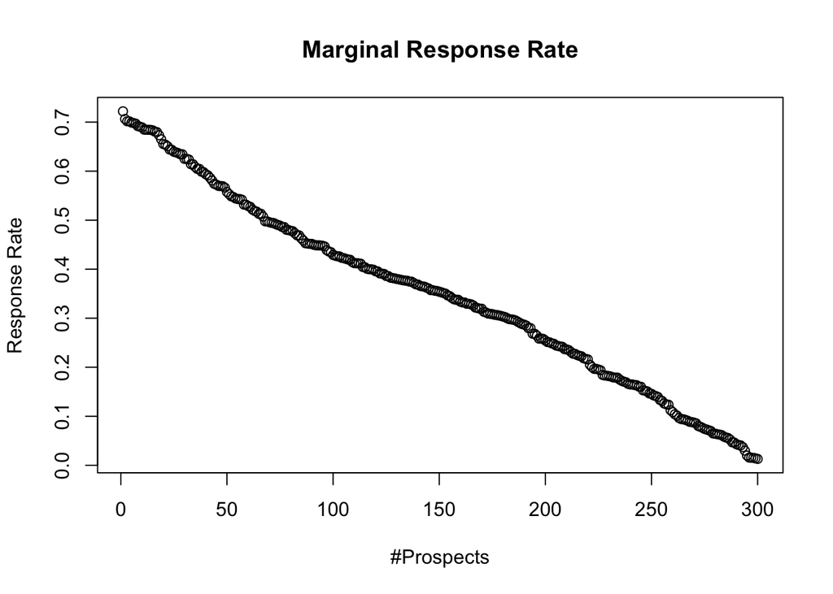

```r
prediction.testing.ResponseSort <- prediction.testing[order(-prediction.testing$BinaryLogitProbability),]
prediction.testing.ResponseSort
# Plot of Marginal Response Rate vs. Number of Prospects Targeted

plot(prediction.testing.ResponseSort$BinaryLogitProbability, main="Marginal Response Rate",
   xlab="#Prospects", ylab="Response Rate")
```

## Results

1. **Cut off response rate**: Given that the average CLV is 30 dollars and the solicitation cost is $12, I can use the Marginal Cost Rule to determine who the CD club should send invitations to. The cutoff response rate is 0.4 because the solicitation cost of 12 dollars divided by the average CLV of 30 dollars is 0.4. Looking at the holdout list in decreasing order of lift, the company should send out to the 1st to the 116th highest prospect because that 116th highest prospect has a binary logit probability of 0.4008 and those after that have a marginal response probability < 0.4.

```r
#Marginal Cost Rule to determine cut off response rate
cut_off <- 12/30
table(prediction.testing$BinaryLogitProbability > 0.4)
```

```
##
## FALSE  TRUE
##   184   116
```

2. **Expected Responses**: Given that the CD club has only 40 items of the collector’s edition of “Pink Floyd’s The Wall”, I can use the Limited Supply Rule to determine which prospects (and how many) on the Testing list should the CD club send an invitation to. I compute the Cumulative Sum (aka running sum) for the Predicted Response Rates in decreasing order. The plot shows the Number of Positive Responses vs. Number of Prospects Targeted. The firm should mail to the 1st to the 64th highest prospects because at the 64th highest prospect, the cumulative sum of the predicted response rate is 39.977 and at the 65th highest prospect, the cumulative sum is 40.007.

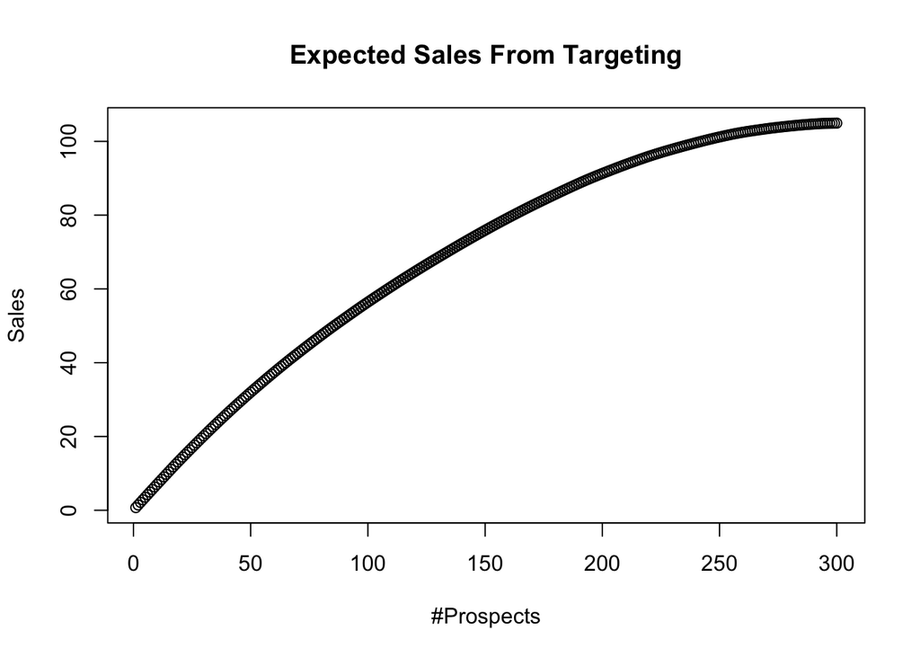

```r
# Expected Responses
CumulativeSum = cumsum(prediction.testing.ResponseSort$BinaryLogitProbability)
plot(CumulativeSum, main="Expected Sales From Targeting",
   xlab="#Prospects", ylab="Sales")
```

```r
full_data<-cbind(prediction.testing.ResponseSort ,CumulativeSum)
table(full_data$CumulativeSum < 40)
```

```
##
## FALSE  TRUE
##   236    64
```

3. **Comparison of Actual to Predicted Response Rates**: To evaluate my predictions, I compare the Actual Response Rates to the Predicted Response Rates for the prospects in the Testing Sample. The plot below shows the two rates superimposed.

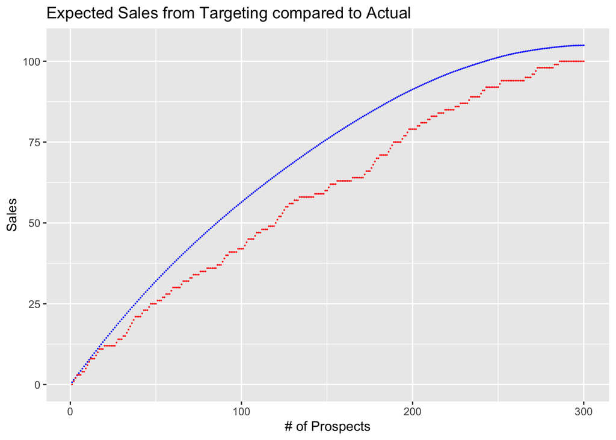

```r
library(ggplot2)
actual.testing <- data.testing[c("id","y")]
actual.testing$predictedresponse <- prediction.testing$BinaryLogitProbability
actual.testing.ResponseSort <- actual.testing[order(-actual.testing$predictedresponse),]
full_data$CumulativeSum.actual = cumsum(actual.testing.ResponseSort$y)
full_data$row_num <- seq.int(nrow(full_data))
p1 <- ggplot( full_data, aes(x = row_num, y = CumulativeSum)) + geom_point(color="blue", size=0.003)
p1 <- p1 + geom_point(aes(x = row_num,y = CumulativeSum.actual), color="red", size=0.003) +  ggtitle("Expected Sales from Targeting compared to Actual")  + labs(x = "# of Prospects", y = "Sales")
p1
```

4. **Profit Impact**: The average and total profit per name with scoring is better. Through this model, I improve average profit per name from -2 dollars to 0.26 dollars, and total profit per name from -600 dollars to 78 dollars.

```r
nhh  = dim(prediction.testing)[1]
targetall.profit = setNames(data.frame(matrix(ncol = 1, nrow = nhh)), c("Profit"))
# Loop over all HH (in our case 300) and calculate the profit based on the model's predicted probabilities
for (i in 1:nhh) {

  # Check whether the consumer did buy
    if (data.testing$y[i]> 0)
      {
        targetall.profit[i,1] = 18
      }
    else
      {
      targetall.profit[i,1] = -12
      }
}
# Average Profit per name WITHOUT Scoring
mean(targetall.profit[,1])
```

```
## [1] -2
```

```r
# Total Profit per name WITHOUT Scoring
sum(targetall.profit[,1])
```

```
## [1] -600
```

```r
# 2 Profit using the scoring model
# Create a Dataframe for save the results in (300 HH and one profit each)
prediction.profit = setNames(data.frame(matrix(ncol = 1, nrow = nhh)), c("Profit"))
# Loop over all HH (in our case 300) and caculate the profit based on the model's predicted probabilities
for (i in 1:nhh) {
  # Check for predicted purchase probability > 0.4
    if (prediction.testing$BinaryLogitProbability[i]> 0.4)
      {
      # We target these consumers. Now check whether they would have bought!
      if(data.testing$y[i]>0)
        {
        prediction.profit[i,1] = 18
        }
      else
        {
        prediction.profit[i,1] = -12
        }
      }
    else
      {
      prediction.profit[i,1] = 0
      }
}
# Average Profit per name with Scoring
mean(prediction.profit[,1])
```

```
## [1] 0.26
```

```r
# Total Profit per name with Scoring
sum(prediction.profit[,1])
```

```
## [1] 78
```